[figure not shown]

Métodos de Predictivos (Clasificación o Aprendizaje-Supervisado)

# Índices de Calidad del Modelo y Funciones Auxiliares

**Se necesita cargar las siguientes librerías**

```r
library(tidyverse)
library(glue)
library(scales)
```

**Muestra la distribución de la variable a predecir**

```r
equilibrio.variable.predecir<-function(datos,variable.predecir,ylab="Cantidad de individuos",xlab = "",
                                       main=paste("Distribución de la variable",variable.predecir),
                                       col = NA) {
  gg_color <- function (n) {
     hues <- seq(15, 375, length = n + 1)
     hcl(h = hues, l = 65, c = 100)[1:n]
  }
  if(missing(variable.predecir) | !(variable.predecir %in% colnames(datos))){
    stop("variable.predecir tiene que ser ingresada y ser un nombre de columna", call. = FALSE )
  }
  if(is.character(datos[,variable.predecir]) | is.factor(datos[,variable.predecir])){
    if(length(col) == 0 || is.na(col)){
      col <- gg_color(length(unique(datos[,variable.predecir])))
    }else{
      col <- rep(col,length(unique(datos[,variable.predecir])))
    }
    ggplot(data = datos, mapping = aes_string(x = variable.predecir, fill = variable.predecir)) +
      geom_bar() +
      scale_fill_manual(values = col, name = variable.predecir) +
      labs(x = xlab, y = ylab, title = main) +
      theme_minimal() +
      theme(legend.position = "bottom")
  }else{
    stop("La variable a predecir tienen que ser de tipo factor o character", call. = FALSE )
  }
}
```

**Muestra la distribución de una variable numérica según la variable a predecir**

```r
poder.predictivo.numerica<-function(datos,variable.predecir,variable.comparar,ylab="",xlab="",
                                    main=paste("Densidad de la variable",variable.comparar,'según',variable.predecir),
                                    col=NA){
  gg_color <- function (n) {
     hues <- seq(15, 375, length = n + 1)
     hcl(h = hues, l = 65, c = 100)[1:n]
  }
  if(missing(variable.predecir) | !(variable.predecir %in% colnames(datos))){
    stop("variable.predecir tiene que ser ingresada y ser un nombre de columna", call. = FALSE )
  }
  if(missing(variable.comparar) | !(variable.comparar %in% colnames(datos)) | !is.numeric(datos[,variable.comparar])){
    stop("variable.comparar tiene que ser ingresada y ser un nombre de columna numérica", call. = FALSE )
  }

  if(is.character(datos[,variable.predecir]) | is.factor(datos[,variable.predecir])){
    if(length(col) == 0 || is.na(col)){
      col <- gg_color(length(unique(datos[,variable.predecir])))
    }else{
      col <- rep(col,length(unique(datos[,variable.predecir])))
    }

    ggplot(data = datos, aes_string(variable.comparar, fill = variable.predecir)) +
      geom_density(alpha = .7, color = NA) +
      scale_fill_manual(values = col) +
      labs(title = main , y = ylab, x = xlab ,fill = variable.predecir) +
      theme_minimal() +
      theme(legend.position = 'bottom',
            legend.title = element_blank(),
            text = element_text(size = 15))

  }else{
    stop("La variable a predecir tienen que ser de tipo factor o character", call. = FALSE )
  }
}
```

**Muestra la distribución de una variable categórica según la variable a predecir**

```r
poder.predictivo.categorica<-function(datos,variable.predecir,variable.comparar,ylab="",xlab="",
                                      main=paste("Densidad de la variable",variable.comparar,'según',variable.predecir),
                                      col=NA){
  gg_color <- function (n) {
     hues <- seq(15, 375, length = n + 1)
     hcl(h = hues, l = 65, c = 100)[1:n]
  }
  if(missing(variable.predecir) | !(variable.predecir %in% colnames(datos))){
    stop("variable.predecir tiene que ser ingresada y ser un nombre de columna", call. = FALSE )
  }
  if(missing(variable.comparar) | !(variable.comparar %in% colnames(datos)) |
     !(is.factor(datos[,variable.comparar]) | is.character(datos[,variable.comparar])) ){
    stop("variable.comparar tiene que ser ingresada y ser un nombre de columna categórica", call. = FALSE )
  }

  if(is.character(datos[,variable.predecir]) | is.factor(datos[,variable.predecir])){
    if(length(col) == 0 || is.na(col)){
      col <- gg_color(length(unique(datos[,variable.predecir])))
    }else{
      col <- rep(col,length(unique(datos[,variable.predecir])))
    }

    datos2 <- datos %>%
      dplyr::group_by_(variable.comparar, variable.predecir) %>%
      dplyr::summarise(count = n())

    if(variable.comparar != variable.predecir){
      datos2 <-   datos2 %>% dplyr::group_by_(variable.comparar)
    }
    datos2 <- datos2 %>% dplyr::mutate(prop = round(count/sum(count),4))

    ggplot(data = datos2, mapping = aes_string(x = variable.comparar, y = "prop", fill = variable.predecir)) +
      geom_col(position = "fill") +
      geom_text(aes(label = glue("{percent(prop)} ({count})")), position = position_stack(vjust = .5), color = "white") +
      scale_y_continuous(label = percent) +
      labs(y =  xlab, x  = ylab, title = main) +
      scale_fill_manual(values = col, name = variable.predecir) +
      theme(legend.position = "bottom")+
      coord_flip()

  }else{
    stop("La variable a predecir tienen que ser de tipo factor o character", call. = FALSE )
  }
}
```

**Índices para matrices NxN**

```r
indices.general <- function(MC) {
  precision.global <- sum(diag(MC))/sum(MC)
  error.global <- 1 - precision.global
  precision.categoria <- diag(MC)/rowSums(MC)
  res <- list(matriz.confusion = MC, precision.global = precision.global, error.global = error.global,
              precision.categoria = precision.categoria)
  names(res) <- c("Matriz de Confusión", "Precisión Global", "Error Global",
                  "Precisión por categoría")
  return(res)
}
```

# El método de XGBoosting

## Métodos de Potenciación - eXtreme Gradient Boosting

Este método se puede aplicar para 2 categorías o más, pero la forma de implementarlo cambia.

### 2 Categorías - Ejemplo Scoring

```r
setwd("~/Desktop/Datos/")
datos<-read.csv("MuestraCredito5000V2.csv",sep = ";",header=T)

# Recodifica las variables como categóricas ordinales
datos$IngresoNeto <- factor(datos$IngresoNeto, ordered = TRUE)
datos$CoefCreditoAvaluo <- factor(datos$CoefCreditoAvaluo, ordered = TRUE)
```

```r
datos
```

| MontoCredito | IngresoNeto | CoefCreditoAvaluo | MontoCuota | GradoAcademico | BuenPagador |
| --- | --- | --- | --- | --- | --- |
| 14327 | 1 | 1 | MuyBajo | Bachiller | Si |
| 111404 | 1 | 1 | MuyBajo | Bachiller | Si |
| 21128 | 1 | 1 | MuyBajo | Bachiller | Si |
| 15426 | 2 | 1 | MuyBajo | Bachiller | Si |
| 10351 | 1 | 1 | MuyBajo | Bachiller | Si |
| 27060 | 1 | 1 | MuyBajo | Bachiller | Si |
| 243369 | 1 | 1 | MuyBajo | Bachiller | Si |
| 16300 | 2 | 1 | MuyBajo | Bachiller | Si |
| 18319 | 2 | 1 | MuyBajo | Bachiller | Si |
| 107037 | 2 | 1 | MuyBajo | Bachiller | Si |

[output cut: 4990 more lines]

```r
str(datos)
```

```
'data.frame':   5000 obs. of  6 variables:
 $ MontoCredito     : int  14327 111404 21128 15426 10351 27060 243369 16300 18319 107037 ...
 $ IngresoNeto      : Ord.factor w/ 2 levels "1"<"2": 1 1 1 2 1 1 1 2 2 2 ...
 $ CoefCreditoAvaluo: Ord.factor w/ 12 levels "1"<"2"<"3"<"4"<..: 1 1 1 1 1 1 1 1 1 1 ...
 $ MontoCuota       : Factor w/ 4 levels "Alto","Bajo",..: 4 4 4 4 4 4 4 4 4 4 ...
 $ GradoAcademico   : Factor w/ 2 levels "Bachiller","Licenciatura": 1 1 1 1 1 1 1 1 1 1 ...
 $ BuenPagador      : Factor w/ 2 levels "No","Si": 2 2 2 2 2 2 2 2 2 2 ...
```

### Distribución de las categorías

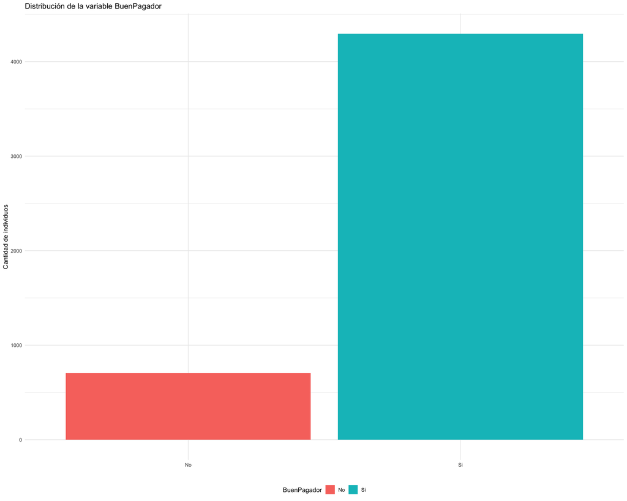

```r
equilibrio.variable.predecir(datos,"BuenPagador")
```

### Predicción

Vamos a generar al azar una tabla de testing con 15% de los datos y una tabla de aprendizaje con 85%

```r
muestra <- sample(1:nrow(datos), floor(nrow(datos)*0.15))
ttesting <- datos[muestra,]
taprendizaje <- datos[-muestra,]
```

### Paquete xgboost

**Se cargan las librerías**

```r
library(xgboost)
```

**Para usar este método las variables tiene que ser numéricas y la variables a predecir tiene que tener valores tener valores `0` o `1`**

```r
taprendizaje2   <- taprendizaje
taprendizaje2[] <- lapply(taprendizaje, as.numeric)
taprendizaje2
```

|  | MontoCredito | IngresoNeto | CoefCreditoAvaluo | MontoCuota | GradoAcademico | BuenPagador |
| --- | --- | --- | --- | --- | --- | --- |
| 1 | 14327 | 1 | 1 | 4 | 1 | 2 |
| 2 | 111404 | 1 | 1 | 4 | 1 | 2 |
| 3 | 21128 | 1 | 1 | 4 | 1 | 2 |
| 4 | 15426 | 2 | 1 | 4 | 1 | 2 |
| 5 | 10351 | 1 | 1 | 4 | 1 | 2 |
| 6 | 27060 | 1 | 1 | 4 | 1 | 2 |
| 7 | 243369 | 1 | 1 | 4 | 1 | 2 |
| 9 | 18319 | 2 | 1 | 4 | 1 | 2 |
| 10 | 107037 | 2 | 1 | 4 | 1 | 2 |
| 11 | 10149 | 1 | 1 | 4 | 1 | 2 |

[output cut: 4240 more lines]

```r
ttesting2   <- ttesting
ttesting2[] <- lapply(ttesting, as.numeric)
ttesting2
```

|  | MontoCredito | IngresoNeto | CoefCreditoAvaluo | MontoCuota | GradoAcademico | BuenPagador |
| --- | --- | --- | --- | --- | --- | --- |
| 2940 | 99821 | 1 | 12 | 2 | 1 | 2 |
| 4861 | 13886 | 1 | 11 | 3 | 1 | 1 |
| 3855 | 18898 | 2 | 11 | 3 | 2 | 2 |
| 2832 | 28885 | 2 | 12 | 2 | 1 | 2 |
| 3929 | 26620 | 2 | 12 | 3 | 1 | 2 |
| 3796 | 12533 | 2 | 5 | 3 | 2 | 2 |
| 2305 | 15095 | 1 | 11 | 1 | 1 | 1 |
| 4793 | 10900 | 2 | 6 | 3 | 1 | 1 |
| 317 | 19782 | 2 | 12 | 2 | 1 | 2 |
| 2552 | 74280 | 1 | 12 | 4 | 1 | 2 |

[output cut: 740 more lines]

**En este caso `BuenPagador` tiene valores de `1` y `2`, por lo que hay que arreglar estos valores para que sean valores `0` y `1`**

```r
taprendizaje2$BuenPagador <- taprendizaje2$BuenPagador - 1
taprendizaje2
```

|  | MontoCredito | IngresoNeto | CoefCreditoAvaluo | MontoCuota | GradoAcademico | BuenPagador |
| --- | --- | --- | --- | --- | --- | --- |
| 1 | 14327 | 1 | 1 | 4 | 1 | 1 |
| 2 | 111404 | 1 | 1 | 4 | 1 | 1 |
| 3 | 21128 | 1 | 1 | 4 | 1 | 1 |
| 4 | 15426 | 2 | 1 | 4 | 1 | 1 |
| 5 | 10351 | 1 | 1 | 4 | 1 | 1 |
| 6 | 27060 | 1 | 1 | 4 | 1 | 1 |
| 7 | 243369 | 1 | 1 | 4 | 1 | 1 |
| 9 | 18319 | 2 | 1 | 4 | 1 | 1 |
| 10 | 107037 | 2 | 1 | 4 | 1 | 1 |
| 11 | 10149 | 1 | 1 | 4 | 1 | 1 |

[output cut: 4240 more lines]

```r
ttesting2$BuenPagador <- ttesting2$BuenPagador - 1
ttesting2
```

|  | MontoCredito | IngresoNeto | CoefCreditoAvaluo | MontoCuota | GradoAcademico | BuenPagador |
| --- | --- | --- | --- | --- | --- | --- |
| 2940 | 99821 | 1 | 12 | 2 | 1 | 1 |
| 4861 | 13886 | 1 | 11 | 3 | 1 | 0 |
| 3855 | 18898 | 2 | 11 | 3 | 2 | 1 |
| 2832 | 28885 | 2 | 12 | 2 | 1 | 1 |
| 3929 | 26620 | 2 | 12 | 3 | 1 | 1 |
| 3796 | 12533 | 2 | 5 | 3 | 2 | 1 |
| 2305 | 15095 | 1 | 11 | 1 | 1 | 0 |
| 4793 | 10900 | 2 | 6 | 3 | 1 | 0 |
| 317 | 19782 | 2 | 12 | 2 | 1 | 1 |
| 2552 | 74280 | 1 | 12 | 4 | 1 | 1 |

[output cut: 740 more lines]

**El paquete xgboost necesita los datos en un formato específico**

```r
taprendizaje2 <- xgb.DMatrix(data = data.matrix(taprendizaje2[,-6]),
                             label = data.matrix(taprendizaje2$BuenPagador))
ttesting2 <- xgb.DMatrix(data = data.matrix(ttesting2[,-6]),
                         label = data.matrix(ttesting2$BuenPagador))
```

**Se genera el modelo**

```r
# Parámetros del modelo
parametros <- list(booster = "gbtree", objective = "binary:logistic", eta=0.3,
               gamma=0, max_depth=6, min_child_weight=1, subsample=1, colsample_bytree=1)

modelo <- xgb.train (params = parametros, data = taprendizaje2, nrounds = 79,
                  watchlist = list(train=taprendizaje2), print_every_n = 10,
                  early_stop_round = 10, maximize = F , eval_metric = "error")
modelo
```

```
##### xgb.Booster
raw: 137.5 Kb
call:
  xgb.train(params = parametros, data = taprendizaje2, nrounds = 79,
    watchlist = list(train = taprendizaje2), print_every_n = 10,
    maximize = F, early_stop_round = 10, eval_metric = "error")
params (as set within xgb.train):
  booster = "gbtree", objective = "binary:logistic", eta = "0.3", gamma = "0", max_depth = "6", min_child_weight = "1", subsample = "1", colsample_bytree = "1", early_stop_round = "10", eval_metric = "error", silent = "1"
xgb.attributes:
  niter
callbacks:
  cb.print.evaluation(period = print_every_n)
  cb.evaluation.log()
# of features: 5
niter: 79
nfeatures : 5
evaluation_log:
    iter train_error
       1    0.051529
       2    0.050588
---
      78    0.029176
      79    0.029176
```

**Se genera la predicción**

```r
prediccion <- predict (modelo, ttesting2)
head(prediccion, n = 25)
```

```
 [1] 0.936370671 0.019916438 0.993476927 0.992488384 0.988893092
 [6] 0.998554766 0.001624209 0.173977777 0.994808495 0.907197416
[11] 0.962629080 0.990568340 0.985719979 0.996085286 0.994952917
[16] 0.755268633 0.959817708 0.990427613 0.008926642 0.866528869
[21] 0.984998643 0.994269967 0.984999359 0.949427426 0.851030529
```

**Para obtener las clases podemos hacer lo siguiente:**

```r
clases <- levels(datos$BuenPagador)
prediccion <- ifelse (prediccion > 0.5, clases[2], clases[1])
prediccion
```

```
  [1] "Si" "No" "Si" "Si" "Si" "Si" "No" "No" "Si" "Si" "Si" "Si" "Si" "Si"
 [15] "Si" "Si" "Si" "Si" "No" "Si" "Si" "Si" "Si" "Si" "Si" "Si" "Si" "Si"
 [29] "Si" "Si" "Si" "Si" "No" "Si" "Si" "Si" "Si" "Si" "Si" "Si" "Si" "Si"
 [43] "Si" "No" "Si" "No" "Si" "No" "No" "Si" "Si" "Si" "Si" "Si" "No" "Si"
 [57] "Si" "Si" "Si" "Si" "Si" "Si" "Si" "Si" "Si" "Si" "Si" "Si" "Si" "Si"
 [71] "Si" "Si" "Si" "Si" "Si" "Si" "Si" "Si" "Si" "Si" "Si" "Si" "No" "Si"
 [85] "No" "Si" "Si" "No" "Si" "Si" "Si" "Si" "Si" "Si" "No" "Si" "No" "Si"
 [99] "Si" "Si" "Si" "Si" "Si" "Si" "No" "Si" "Si" "Si" "No" "Si" "Si" "Si"
[113] "Si" "Si" "Si" "Si" "Si" "Si" "Si" "Si" "Si" "Si" "Si" "Si" "Si" "Si"
[127] "Si" "Si" "Si" "Si" "Si" "Si" "Si" "Si" "Si" "Si" "Si" "Si" "Si" "Si"
[141] "Si" "No" "Si" "Si" "No" "Si" "Si" "Si" "Si" "Si" "Si" "Si" "Si" "Si"
[155] "No" "Si" "Si" "Si" "Si" "Si" "Si" "Si" "Si" "Si" "Si" "Si" "Si" "Si"
[169] "Si" "Si" "No" "Si" "Si" "No" "Si" "No" "No" "Si" "No" "Si" "Si" "Si"
[183] "Si" "Si" "Si" "Si" "No" "Si" "Si" "Si" "Si" "Si" "Si" "Si" "Si" "Si"
[197] "Si" "Si" "Si" "Si" "Si" "Si" "Si" "Si" "Si" "No" "Si" "Si" "Si" "Si"
```

[output cut: 39 more lines]

**Se genera la matriz de confusión**

```r
MC <- table(ttesting[,6], as.factor(prediccion))
MC
```

```
      No  Si
  No  94  29
  Si  10 617
```

**Índices de calidad de la predicción**

```r
indices <- indices.general(MC)
indices
```

```
$`Matriz de Confusión`

      No  Si
  No  94  29
  Si  10 617

$`Precisión Global`
[1] 0.948

$`Error Global`
[1] 0.052

$`Precisión por categoría`
       No        Si
0.7642276 0.9840510
```

### Paquete trainR

**Se cargan las librerías**

```r
library(trainR)
```

**Se genera el modelo**

```r
modelo <- train.xgboost(BuenPagador~.,data = taprendizaje, nrounds = 79,
                        print_every_n = 10, maximize = F , eval_metric = "error")
modelo
```

```
##### xgb.Booster
raw: 137.5 Kb
call:
  xgb.train(params = params, data = train_aux, nrounds = nrounds,
    watchlist = watchlist, obj = obj, feval = feval, verbose = verbose,
    print_every_n = print_every_n, early_stopping_rounds = early_stopping_rounds,
    maximize = maximize, save_period = save_period, save_name = save_name,
    xgb_model = xgb_model, callbacks = callbacks)
params (as set within xgb.train):
  booster = "gbtree", objective = "binary:logistic", eta = "0.3", gamma = "0", max_depth = "6", min_child_weight = "1", subsample = "1", colsample_bytree = "1", silent = "1"
xgb.attributes:
  niter
callbacks:
  cb.print.evaluation(period = print_every_n)
  cb.evaluation.log()
# of features: 5
niter: 79
nfeatures : 5
evaluation_log:
    iter train_error
       1    0.051529
       2    0.050588
---
      78    0.029176
      79    0.029176
```

**Se genera la predicción**

```r
prediccion <- predict(modelo, ttesting)
prediccion
```

```
  [1] Si No Si Si Si Si No No Si Si Si Si Si Si Si Si Si Si No Si Si Si Si
 [24] Si Si Si Si Si Si Si Si Si No Si Si Si Si Si Si Si Si Si Si No Si No
 [47] Si No No Si Si Si Si Si No Si Si Si Si Si Si Si Si Si Si Si Si Si Si
 [70] Si Si Si Si Si Si Si Si Si Si Si Si Si No Si No Si Si No Si Si Si Si
 [93] Si Si No Si No Si Si Si Si Si Si Si No Si Si Si No Si Si Si Si Si Si
[116] Si Si Si Si Si Si Si Si Si Si Si Si Si Si Si Si Si Si Si Si Si Si Si
[139] Si Si Si No Si Si No Si Si Si Si Si Si Si Si Si No Si Si Si Si Si Si
[162] Si Si Si Si Si Si Si Si Si No Si Si No Si No No Si No Si Si Si Si Si
[185] Si Si No Si Si Si Si Si Si Si Si Si Si Si Si Si Si Si Si Si Si No Si
[208] Si Si Si No Si Si Si Si Si Si Si No Si Si Si Si Si Si Si Si No Si Si
[231] Si Si Si Si Si Si Si Si Si No Si Si Si Si No No Si No Si Si Si Si Si
[254] Si Si Si Si Si Si Si Si Si Si No No Si Si Si Si Si Si Si No Si Si Si
[277] Si No Si Si Si Si Si Si Si Si Si Si Si Si No Si Si Si No Si Si Si Si
[300] Si Si Si Si Si Si Si Si No Si Si Si Si Si Si Si No No No No Si Si Si
[323] No No Si Si Si Si Si Si Si Si Si No Si Si Si Si Si Si No Si Si Si Si
```

[output cut: 19 more lines]

**Se genera la matriz de confusión**

```r
MC <- confusion.matrix(ttesting, prediccion)
MC
```

```
    prediction
real  No  Si
  No  94  29
  Si  10 617
```

**Índices de calidad de la predicción**

```r
indices <- general.indexes(mc = MC)
indices
```

```
Confusion Matrix:
    prediction
real  No  Si
  No  94  29
  Si  10 617

Overall Accuracy: 0.9480
Overall Error:    0.0520

Category Accuracy:

           No           Si
     0.764228     0.984051
```

**Podemos omitir crear la matriz de confusión**

```r
indices <- general.indexes(ttesting, prediccion)
indices
```

```
Confusion Matrix:
    prediction
real  No  Si
  No  94  29
  Si  10 617

Overall Accuracy: 0.9480
Overall Error:    0.0520

Category Accuracy:

           No           Si
     0.764228     0.984051
```

### Para más de 2 Categorías - Ejemplo Iris

```r
setwd("~/Desktop/Datos/")
datos<-read.csv("iris.csv",sep = ";",dec='.',header=T)
datos
```

| s.largo | s.ancho | p.largo | p.ancho | tipo |
| --- | --- | --- | --- | --- |
| 5.1 | 3.5 | 1.4 | 0.2 | setosa |
| 4.9 | 3.0 | 1.4 | 0.2 | setosa |
| 4.7 | 3.2 | 1.3 | 0.2 | setosa |
| 4.6 | 3.1 | 1.5 | 0.2 | setosa |
| 5.0 | 3.6 | 1.4 | 0.2 | setosa |
| 5.4 | 3.9 | 1.7 | 0.4 | setosa |
| 4.6 | 3.4 | 1.4 | 0.3 | setosa |
| 5.0 | 3.4 | 1.5 | 0.2 | setosa |
| 4.4 | 2.9 | 1.4 | 0.2 | setosa |
| 4.9 | 3.1 | 1.5 | 0.1 | setosa |

[output cut: 140 more lines]

```r
str(datos)
```

```
'data.frame':   150 obs. of  5 variables:
 $ s.largo: num  5.1 4.9 4.7 4.6 5 5.4 4.6 5 4.4 4.9 ...
 $ s.ancho: num  3.5 3 3.2 3.1 3.6 3.9 3.4 3.4 2.9 3.1 ...
 $ p.largo: num  1.4 1.4 1.3 1.5 1.4 1.7 1.4 1.5 1.4 1.5 ...
 $ p.ancho: num  0.2 0.2 0.2 0.2 0.2 0.4 0.3 0.2 0.2 0.1 ...
 $ tipo   : Factor w/ 3 levels "setosa","versicolor",..: 1 1 1 1 1 1 1 1 1 1 ...
```

### Distribución de las categorías

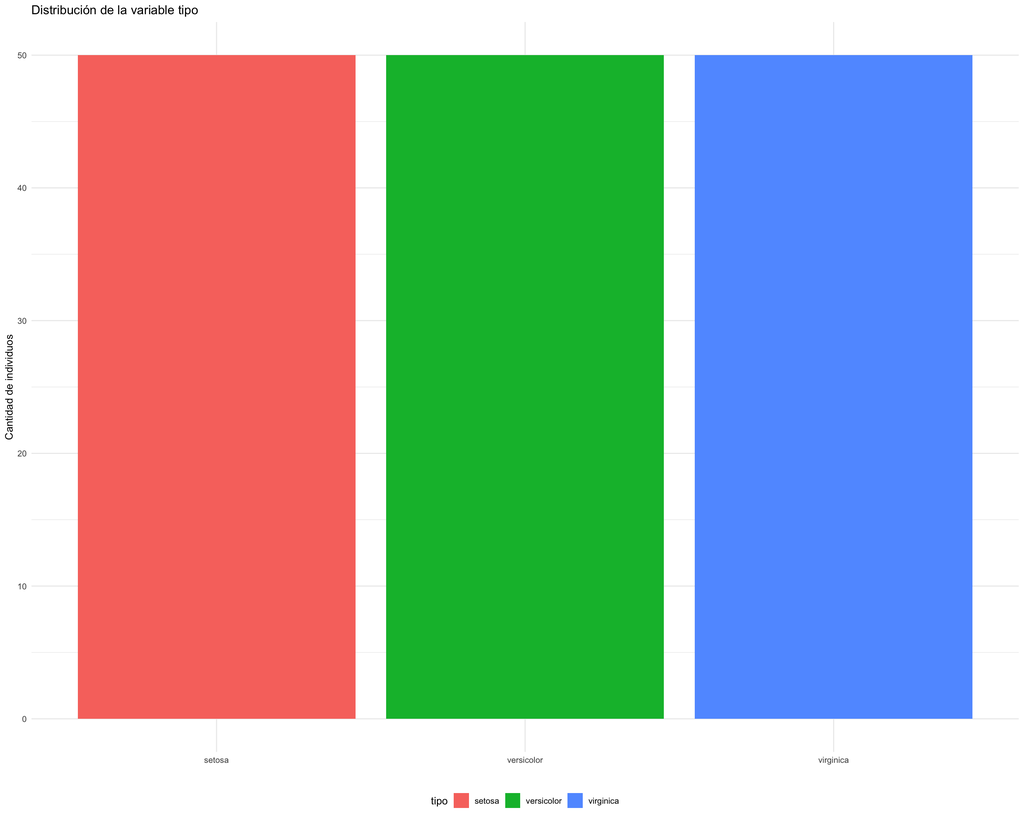

```r
equilibrio.variable.predecir(datos, "tipo")
```

### Predicción

Vamos a generar al azar una tabla de testing de tamaño 50 y una tabla de aprendizaje de tamaño 100.

```r
muestra <- sample(1:nrow(datos), 50)
ttesting <- datos[muestra,]
taprendizaje <- datos[-muestra,]
```

### Paquete xgboost

**Se cargan las librerías**

```r
library(xgboost)
```

**Para usar este método las variables tiene que ser numéricas y la variables a predecir tiene que ser numérica y comenzar en `0`**

```r
taprendizaje2   <- taprendizaje
taprendizaje2[] <- lapply(taprendizaje, as.numeric)
taprendizaje2
```

|  | s.largo | s.ancho | p.largo | p.ancho | tipo |
| --- | --- | --- | --- | --- | --- |
| 1 | 5.1 | 3.5 | 1.4 | 0.2 | 1 |
| 2 | 4.9 | 3.0 | 1.4 | 0.2 | 1 |
| 5 | 5.0 | 3.6 | 1.4 | 0.2 | 1 |
| 7 | 4.6 | 3.4 | 1.4 | 0.3 | 1 |
| 8 | 5.0 | 3.4 | 1.5 | 0.2 | 1 |
| 9 | 4.4 | 2.9 | 1.4 | 0.2 | 1 |
| 10 | 4.9 | 3.1 | 1.5 | 0.1 | 1 |
| 11 | 5.4 | 3.7 | 1.5 | 0.2 | 1 |
| 12 | 4.8 | 3.4 | 1.6 | 0.2 | 1 |
| 14 | 4.3 | 3.0 | 1.1 | 0.1 | 1 |

[output cut: 90 more lines]

```r
ttesting2   <- ttesting
ttesting2[] <- lapply(ttesting, as.numeric)
ttesting2
```

|  | s.largo | s.ancho | p.largo | p.ancho | tipo |
| --- | --- | --- | --- | --- | --- |
| 92 | 6.1 | 3.0 | 4.6 | 1.4 | 2 |
| 137 | 6.3 | 3.4 | 5.6 | 2.4 | 3 |
| 72 | 6.1 | 2.8 | 4.0 | 1.3 | 2 |
| 18 | 5.1 | 3.5 | 1.4 | 0.3 | 1 |
| 87 | 6.7 | 3.1 | 4.7 | 1.5 | 2 |
| 34 | 5.5 | 4.2 | 1.4 | 0.2 | 1 |
| 22 | 5.1 | 3.7 | 1.5 | 0.4 | 1 |
| 104 | 6.3 | 2.9 | 5.6 | 1.8 | 3 |
| 138 | 6.4 | 3.1 | 5.5 | 1.8 | 3 |
| 101 | 6.3 | 3.3 | 6.0 | 2.5 | 3 |

[output cut: 40 more lines]

**En este caso `tipo` tiene valores de `1`, `2` y `3`, por lo que hay que arreglar estos valores para que sean valores `0`, `1` y `2`**

```r
taprendizaje2$tipo <- taprendizaje2$tipo - 1
taprendizaje2
```

|  | s.largo | s.ancho | p.largo | p.ancho | tipo |
| --- | --- | --- | --- | --- | --- |
| 1 | 5.1 | 3.5 | 1.4 | 0.2 | 0 |
| 2 | 4.9 | 3.0 | 1.4 | 0.2 | 0 |
| 5 | 5.0 | 3.6 | 1.4 | 0.2 | 0 |
| 7 | 4.6 | 3.4 | 1.4 | 0.3 | 0 |
| 8 | 5.0 | 3.4 | 1.5 | 0.2 | 0 |
| 9 | 4.4 | 2.9 | 1.4 | 0.2 | 0 |
| 10 | 4.9 | 3.1 | 1.5 | 0.1 | 0 |
| 11 | 5.4 | 3.7 | 1.5 | 0.2 | 0 |
| 12 | 4.8 | 3.4 | 1.6 | 0.2 | 0 |
| 14 | 4.3 | 3.0 | 1.1 | 0.1 | 0 |

[output cut: 90 more lines]

```r
ttesting2$tipo <- ttesting2$tipo - 1
ttesting2
```

|  | s.largo | s.ancho | p.largo | p.ancho | tipo |
| --- | --- | --- | --- | --- | --- |
| 92 | 6.1 | 3.0 | 4.6 | 1.4 | 1 |
| 137 | 6.3 | 3.4 | 5.6 | 2.4 | 2 |
| 72 | 6.1 | 2.8 | 4.0 | 1.3 | 1 |
| 18 | 5.1 | 3.5 | 1.4 | 0.3 | 0 |
| 87 | 6.7 | 3.1 | 4.7 | 1.5 | 1 |
| 34 | 5.5 | 4.2 | 1.4 | 0.2 | 0 |
| 22 | 5.1 | 3.7 | 1.5 | 0.4 | 0 |
| 104 | 6.3 | 2.9 | 5.6 | 1.8 | 2 |
| 138 | 6.4 | 3.1 | 5.5 | 1.8 | 2 |
| 101 | 6.3 | 3.3 | 6.0 | 2.5 | 2 |

[output cut: 40 more lines]

**El paquete xgboost necesita los datos en un formato específico**

```r
taprendizaje2 <- xgb.DMatrix(data = data.matrix(taprendizaje2[,-5]),
                             label = data.matrix(taprendizaje2$tipo))
ttesting2 <- xgb.DMatrix(data = data.matrix(ttesting2[,-5]),
                         label = data.matrix(ttesting2$tipo))
```

**Se genera el modelo**

```r
# objective = "multi:softprob" es para múltiples categorías
parametros <- list(booster = "gbtree", objective = "multi:softprob", eta=0.3,
                   gamma=0, max_depth=6, min_child_weight=1, subsample=1,
                   colsample_bytree=1,num_class = 3)

# OJO eval_metric = "mlogloss"
modelo <- xgb.train(params = parametros, data = taprendizaje2, nrounds = 79,
                    watchlist = list(train=taprendizaje2),
                    print_every_n = 10,early_stop_round = 10,
                    maximize = F , eval_metric = "mlogloss")
```

**Se genera la predicción**

```r
prediccion <- predict(modelo, ttesting2)
head(prediccion, n = 25)
```

```
 [1] 0.0103020007 0.9845268726 0.0051710997 0.0004080366 0.0020553230
 [6] 0.9975366592 0.0102188475 0.9846518040 0.0051293606 0.9921517372
[11] 0.0067860186 0.0010622673 0.0099806245 0.9850096107 0.0050097844
[16] 0.9921517372 0.0067860186 0.0010622673 0.9921517372 0.0067860186
[21] 0.0010622673 0.0005623274 0.0028325012 0.9966051579 0.0005946390
```

**Para obtener las clases podemos hacer lo siguiente:**

```r
clases <- levels(datos$tipo)
prediccion <- matrix(prediccion, ncol=3, byrow=TRUE)
prediccion <- clases[max.col(prediccion)]
prediccion
```

```
 [1] "versicolor" "virginica"  "versicolor" "setosa"     "versicolor"
 [6] "setosa"     "setosa"     "virginica"  "virginica"  "virginica"
[11] "versicolor" "virginica"  "versicolor" "setosa"     "versicolor"
[16] "virginica"  "versicolor" "versicolor" "setosa"     "virginica"
[21] "virginica"  "virginica"  "virginica"  "virginica"  "virginica"
[26] "versicolor" "versicolor" "setosa"     "setosa"     "virginica"
[31] "setosa"     "setosa"     "versicolor" "virginica"  "versicolor"
[36] "versicolor" "virginica"  "setosa"     "virginica"  "virginica"
[41] "versicolor" "setosa"     "virginica"  "versicolor" "versicolor"
[46] "virginica"  "virginica"  "setosa"     "setosa"     "setosa"
```

**Se genera la matriz de confusión**

```r
MC <- table(ttesting$tipo, prediccion)
MC
```

```
            prediccion
             setosa versicolor virginica
  setosa         14          0         0
  versicolor      0         14         0
  virginica       0          2        20
```

**Índices de calidad de la predicción**

```r
indices <- indices.general(MC)
indices
```

```
$`Matriz de Confusión`
            prediccion
             setosa versicolor virginica
  setosa         14          0         0
  versicolor      0         14         0
  virginica       0          2        20

$`Precisión Global`
[1] 0.96

$`Error Global`
[1] 0.04

$`Precisión por categoría`
    setosa versicolor  virginica
 1.0000000  1.0000000  0.9090909
```

### Paquete trainR

**Se cargan las librerías**

```r
library(trainR)
```

**Se genera el modelo**

```r
modelo <- train.xgboost(tipo~.,data = taprendizaje, nrounds = 79,
                        print_every_n = 10, maximize = FALSE)
modelo
```

```
##### xgb.Booster
raw: 65.4 Kb
call:
  xgb.train(params = params, data = train_aux, nrounds = nrounds,
    watchlist = watchlist, obj = obj, feval = feval, verbose = verbose,
    print_every_n = print_every_n, early_stopping_rounds = early_stopping_rounds,
    maximize = maximize, save_period = save_period, save_name = save_name,
    xgb_model = xgb_model, callbacks = callbacks, eval_metric = "mlogloss")
params (as set within xgb.train):
  booster = "gbtree", objective = "multi:softprob", eta = "0.3", gamma = "0", max_depth = "6", min_child_weight = "1", subsample = "1", colsample_bytree = "1", num_class = "3", eval_metric = "mlogloss", silent = "1"
xgb.attributes:
  niter
callbacks:
  cb.print.evaluation(period = print_every_n)
  cb.evaluation.log()
# of features: 4
niter: 79
nfeatures : 4
evaluation_log:
    iter train_mlogloss
       1       0.743491
       2       0.534706
---
      78       0.020802
      79       0.020688
```

**Se genera la predicción**

```r
prediccion <- predict(modelo, ttesting)
prediccion
```

```
 [1] versicolor virginica  versicolor setosa     versicolor setosa
 [7] setosa     virginica  virginica  virginica  versicolor virginica
[13] versicolor setosa     versicolor virginica  versicolor versicolor
[19] setosa     virginica  virginica  virginica  virginica  virginica
[25] virginica  versicolor versicolor setosa     setosa     virginica
[31] setosa     setosa     versicolor virginica  versicolor versicolor
[37] virginica  setosa     virginica  virginica  versicolor setosa
[43] virginica  versicolor versicolor virginica  virginica  setosa
[49] setosa     setosa
Levels: setosa versicolor virginica
```

**Se genera la matriz de confusión**

```r
MC <- confusion.matrix(ttesting, prediccion)
MC
```

```
            prediction
real         setosa versicolor virginica
  setosa         14          0         0
  versicolor      0         14         0
  virginica       0          2        20
```

**Índices de calidad de la predicción**

```r
indices <- general.indexes(mc = MC)
indices
```

```
Confusion Matrix:
            prediction
real         setosa versicolor virginica
  setosa         14          0         0
  versicolor      0         14         0
  virginica       0          2        20

Overall Accuracy: 0.9600
Overall Error:    0.0400

Category Accuracy:

       setosa   versicolor    virginica
     1.000000     1.000000     0.909091
```

**Podemos omitir crear la matriz de confusión**

```r
indices <- general.indexes(ttesting, prediccion)
indices
```

```
Confusion Matrix:
            prediction
real         setosa versicolor virginica
  setosa         14          0         0
  versicolor      0         14         0
  virginica       0          2        20

Overall Accuracy: 0.9600
Overall Error:    0.0400

Category Accuracy:

       setosa   versicolor    virginica
     1.000000     1.000000     0.909091
```